# **Transport Planning Method Assignment 1**

Wanying Sun(2516202S)

2/9/2021

**(word count: 1130 words, excluding questions)**

### **1. Download travel survey data and codebook from: https://www.psrc.org/travel-surveys-spring-2014-household-survey.**

##### **a) Calculate total travel distance (find the distance variable from codebook) for each person (personID) and household (hhid) (save them as distance_person and distance_household, respectively; use a hhsurvey-trips file). Provide a summary statistics of total travel distance variable for person and household (Please remove all missing or unexpected data).**

```r
hhsurvey_trips <- read.csv("/Volumes/SALMON/Salmon/UofG/Semester2/TPM/Assignment1/2014-pr3-hhsurvey-trips.csv")

## Total travel distance for each person (personID)
distance_person <- hhsurvey_trips %>%
  select(personID, gdist)
summary(distance_person $ gdist)
```

```
##     Min.  1st Qu.   Median     Mean  3rd Qu.     Max.     NA's
##  -99.000    0.860    2.510    8.609    6.670 4370.900        8
```

**Data cleaning description**  
**The summary table shows that there exist some NA variables and 0 values of variable gdist. Before cleaning the data, we could find that the description of Trip file (2014_readme file, downloaded from https://www.psrc.org/sites/default/files/2014-readme.pdf) showed that ‘If a person took no trips on the target day, that person had no record in the Trip file but did in the Persons file’. In terms of the 0 values, it means the person did not take trips and had no records (or the record is 0) on the target day in Trip file, however, the person/household had the record in the Persons file which meant that 0 value was not an error in this data set. Besides, we try not to discard the number of samples which might have influence to the population estimation. Particularly, the distance was filtered from 0 to 350, which means that one full fuel tank driving distance is around 350 ~ 370 miles. Thus, the data cleaning process of gdist will only discard the NA and -99.000 values whilst keep the values more than or equals to 0 and less than and equals to 350.**

```r
## Total travel distance for person :
distance_person <- distance_person %>%
  filter(gdist >= 0 & gdist <= 350) %>%
  drop_na(gdist) %>%
  group_by(personID) %>%
  summarise(distance_person = sum(gdist)) %>%
  arrange(distance_person)
summary(distance_person)
```

```
##     personID         distance_person
##  Min.   :1.410e+09   Min.   :  0.00
##  1st Qu.:1.410e+09   1st Qu.:  7.18
##  Median :1.410e+09   Median : 16.71
##  Mean   :1.410e+09   Mean   : 25.36
##  3rd Qu.:1.410e+09   3rd Qu.: 33.83
##  Max.   :1.411e+09   Max.   :970.80
```

```r
distance_person
```

```
## # A tibble: 10,816 x 2
##      personID distance_person
##         <int>           <dbl>
##  1 1410150601            0
##  2 1410305603            0
##  3 1410369501            0
##  4 1410429602            0
##  5 1410432403            0
##  6 1410455701            0
##  7 1410455702            0
##  8 1410463602            0
##  9 1410142802            0.06
## 10 1410212702            0.08
## # … with 10,806 more rows
```

```r
## Total travel distance for each household (hhid):
distance_household <- hhsurvey_trips %>%
  select(hhid, gdist)
summary(distance_household $ gdist)
```

```
##     Min.  1st Qu.   Median     Mean  3rd Qu.     Max.     NA's
##  -99.000    0.860    2.510    8.609    6.670 4370.900        8
```

```r
# Then we do the same data cleaning process as person to household below
# In household data, we do not set an upper limitation for the travel distance,
# because we could not tell how many travel family members of each family every day,
# there is not a baseline for the upper limit.
distance_household <- distance_household %>%
  filter(gdist >= 0) %>%
  drop_na(gdist) %>%
  group_by(hhid) %>%
  summarise(distance_household = sum(gdist))%>%
  arrange(distance_household)
summary(distance_household)
```

```
##       hhid          distance_household
##  Min.   :14100001   Min.   :   0.00
##  1st Qu.:14101521   1st Qu.:  13.45
##  Median :14103031   Median :  32.15
##  Mean   :14103040   Mean   :  71.01
##  3rd Qu.:14104558   3rd Qu.:  63.30
##  Max.   :14106094   Max.   :7372.68
```

```r
distance_household
```

```
## # A tibble: 5,813 x 2
##        hhid distance_household
##       <int>              <dbl>
##  1 14101506               0
##  2 14104557               0
##  3 14102566               0.08
##  4 14102546               0.14
##  5 14103808               0.14
##  6 14105397               0.16
##  7 14102081               0.17
##  8 14105714               0.18
##  9 14101030               0.2
## 10 14102282               0.2
## # … with 5,803 more rows
```

```r
di_all <- rbind(dim(distance_person), dim(distance_household))
rownames(di_all) <- c("Person", "Household")
colnames(di_all) <- c("Record numbers", "Variable numbers")
kbl(di_all,
    caption = "Table 1.1(a) Number of records of person and household",
    align = "c") %>%
   kable_styling(bootstrap_options = "striped",
                 font_size = 15) %>%
  kable_classic(full_width = F, html_font = "Calibri")
```

Table 1.1(a) Number of records of person and household

|  | Record numbers | Variable numbers |
| --- | --- | --- |
| Person | 10816 | 2 |
| Household | 5813 | 2 |

**Total travel distance for each person and household table description:**  
Overall, the tables above gave the total distance information of each person and household respectively.  
In ‘Total travel distance for person’ table, the farthest travel distance was 970.8 miles and the least was 0 among the 10816 records. We could notice that there were eight people (IDs are 1410150601, 1410305603, 1410369501, 1410429602, 1410432403, 1410455701, 1410455702, 1410463602 respectively) with 0 travel distance which meant that those people did not have travel records on the target day.  
Similarly, there were 5813 households observations in ‘Total travel distance for each household (hhid)’ table, the longest travel distance was 7372.68 miles and the shortest was 0 miles.

```r
summary_person <- summary(distance_person $ distance_person)
summary_household <- summary(distance_household $ distance_household)
summary_statistics <- rbind(summary_person, summary_household)
rownames(summary_statistics) <- c("Summary to person", "Summary to household")
kbl(summary_statistics,
    caption = "Table 1.2(a) Summary statistics of total travel distance variable for household",
    align = "c") %>%
   kable_styling(bootstrap_options = "striped",
                 font_size = 15) %>%
    kable_classic(full_width = F, html_font = "Calibri")
```

Table 1.2(a) Summary statistics of total travel distance variable for household

|  | Min. | 1st Qu. | Median | Mean | 3rd Qu. | Max. |
| --- | --- | --- | --- | --- | --- | --- |
| Summary to person | 0 | 7.18 | 16.71 | 25.36066 | 33.8325 | 970.80 |
| Summary to household | 0 | 13.45 | 32.15 | 71.00556 | 63.3000 | 7372.68 |

**Q1(a) Summary statistics of table1.2:**  
Table 1.2(a) showed the statistics information of the total travel distance of each person and household. Overall, all the travel distance of households were higher than each person. Both minimum values are 0 whereas households got longer max travel distance, accounting for 7372.68, and that of person’s was 970.80. The mean distance and the median of both were about 71 and 25, 32 and 16 respectively.

##### **b) Create new data (household) that includes household id, number of vehicles, household size, number of workers in household. Please remove all missing values (including prefer not to answer). Display summary statistics of all variables in the data except id. Find its dimensions.**

```r
hhsurvey_households <- read.csv("/Volumes/SALMON/Salmon/UofG/Semester2/TPM/Assignment1/2014-pr3-hhsurvey-households.csv")
## Select household id, number of vehicles, household size, number of workers from household:
household <- hhsurvey_households %>%
  select(hhid, vehicle_count, hhsize, numworkers)
summary(household)
```

```
##       hhid          vehicle_count        hhsize        numworkers
##  Min.   :14100001   Min.   : 0.000   Min.   :1.000   Min.   :0.000
##  1st Qu.:14101522   1st Qu.: 1.000   1st Qu.:1.000   1st Qu.:1.000
##  Median :14103038   Median : 1.000   Median :2.000   Median :1.000
##  Mean   :14103044   Mean   : 1.566   Mean   :2.021   Mean   :1.133
##  3rd Qu.:14104567   3rd Qu.: 2.000   3rd Qu.:2.000   3rd Qu.:2.000
##  Max.   :14106094   Max.   :10.000   Max.   :8.000   Max.   :7.000
```

```r
household <- household %>%      #filtered household data
  filter(hhid >= 0, vehicle_count >= 0, hhsize >= 0, numworkers >= 0)
summary_exceptID <- rbind(summary(household $ vehicle_count), summary(household $ hhsize), summary(household $ numworkers))
rownames(summary_exceptID) <- c("Number of vehicles", "Household size", "Number of workers")
kbl(summary_exceptID,
    caption = "Table 1.1(b) Summary statistics of number of vehicles, household size, number of workers in household",
    align = "ccc") %>%
   kable_styling(bootstrap_options = "striped",
                 font_size = 15) %>%
  kable_classic(full_width = T, html_font = "Calibri")
```

Table 1.1(b) Summary statistics of number of vehicles, household size, number of workers in household

|  | Min. | 1st Qu. | Median | Mean | 3rd Qu. | Max. |
| --- | --- | --- | --- | --- | --- | --- |
| Number of vehicles | 0 | 1 | 1 | 1.566103 | 2 | 10 |
| Household size | 1 | 1 | 2 | 2.020875 | 2 | 8 |
| Number of workers | 0 | 1 | 1 | 1.133035 | 2 | 7 |

```r
## Creat a new dataset of all variables except ID and print out the dimensions:
all_exceptID_data <- household %>%
  select(-hhid)
da <- dim(all_exceptID_data)
daty <- as.data.frame(da)
rownames(daty) <- c("Number of objections", "Number of variables")
colnames(daty) <- c("Number")
kbl(daty,
    caption = "Table 1.2(b) Dimensions of number of vehicles, household size, and number of workers in household",
    align = "ccc") %>%
   kable_styling(bootstrap_options = "striped",
                 font_size = 15) %>%
    kable_classic(full_width = T, html_font = "Calibri")
```

Table 1.2(b) Dimensions of number of vehicles, household size, and number of workers in household

|  | Number |
| --- | --- |
| Number of objections | 6036 |
| Number of variables | 3 |

##### **c) Display the data contained in the first 10 rows and in all columns except column 4.**

```r
display_household <- as.data.frame(household[1:10,-4])
kbl(display_household,
    caption = "Table 1.1(c) The first 10 rows of household",
    col.names = c("Household ID", "Number of Vehicles", "Household size"),
    align = "ccc") %>%
   kable_styling(bootstrap_options = "striped",
                 font_size = 15) %>%
  kable_classic(full_width = T, html_font = "Calibri")
```

Table 1.1(c) The first 10 rows of household

| Household ID | Number of Vehicles | Household size |
| --- | --- | --- |
| 14100001 | 1 | 1 |
| 14100002 | 1 | 2 |
| 14100003 | 1 | 1 |
| 14100004 | 1 | 1 |
| 14100005 | 1 | 1 |
| 14100006 | 0 | 2 |
| 14100007 | 1 | 1 |
| 14100008 | 0 | 1 |
| 14100009 | 1 | 2 |
| 14100010 | 0 | 2 |

##### **d) Merge new data (household) and total travel distance for household (distance_household). What is the correlation between total travel distance and household size? Draw a histogram of log (total travel distance). Order the data by total travel distance, smallest to largest. (for this problem, please google to find proper functions. You can also find a way to insert title and axis labels).**

```r
household_merge <- merge(household, distance_household) %>%
  arrange(distance_household)
cor(household_merge $ distance_household, household_merge $ hhsize)
```

```
## [1] 0.1054564
```

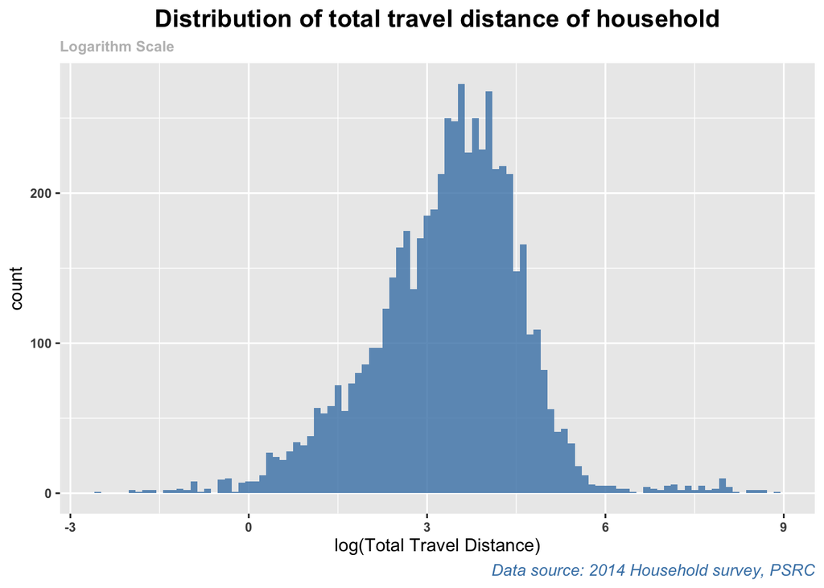

```r
ggplot(household_merge, aes(x = log(household_merge $ distance_household))) +
  labs(x = "log(Total Travel Distance)",
       y = "count",
       title = "Distribution of total travel distance of household",
       subtitle = "Logarithm Scale",
       caption = "Data source: 2014 Household survey, PSRC") +
  geom_histogram(alpha = 0.8,
                 position = "identity",
                 bins = 100,
                 fill = "steelblue") +
  scale_fill_discrete(h = c(250, 10)) +
  theme(plot.title = element_text(colour = "black", size = 15, face = "bold", hjust = 0.5),
        plot.caption = element_text(colour = "steelblue", size = 10, face = "italic", hjust = 1),
        plot.subtitle = element_text(colour = "grey", size = 9, face = "bold"),
        axis.text.x = element_text(face = "bold", size = 8),
        axis.text.y = element_text(face = "bold", size = 8))
```

### **2. Please run a multiple linear regression of your own choosing. You can choose any dependent variable that you are interested in.**

##### **a) Write your equation**

The equation for this multiple linear regression model could be:
$$Y_i\sim N(\alpha+\beta_1*X_1{_i}+\beta_2*X_2{_i}+\beta_3*X_3{_i}+\beta_4*X_4{_i}+\beta_5*X_5{_i}, \sigma^2),\ i = 1, 2,..., 5$$
$X_1: gtime\ (driving\ travel\ time\ (minutes)\ from\ origin\ to\ destination)\\X_2:{trip\underline{ }dur\underline{ }reported}\ (trip\ duration\ in\ minutes)\\X_3: {implied\underline{ }speed\underline{ }mph}\ (implied\ speed\ (miles/hour))\\X_4:{travelers\underline{ }total}\ (total\ number\ of\ travelers\ on\ trip\ including\ self)\\X_5:{mtime\underline{ }day}\ (peak/off-peak\ periods\ for\ MTIME)$

The interpretation is log(people’s travel distance) in Seattle for 2014 PSRC investigation follows the normal distribution, and has a mean $\alpha+\beta_1*X_1{_i}+\beta_2*X_2{_i}+\beta_3*X_3{_i}+\beta_4*X_4{_i}+\beta_5*X_5{_i}$, a standard deviation $\sigma$.

##### **b) Provide a detailed explanation of your variable choice (i.e., independent variables) with the expected signs of these variables**

```r
hhsurvey_trips <- read.csv("/Volumes/SALMON/Salmon/UofG/Semester2/TPM/Assignment1/2014-pr3-hhsurvey-trips.csv")
dim(hhsurvey_trips)
```

```
## [1] 47918    86
```

```r
hhsurvey_trips <- hhsurvey_trips %>%
  select("hhid", "mtime_day", "gtime", "trip_dur_reported", "implied_speed_mph", "travelers_total", "gdist")
summary(hhsurvey_trips)
```

```
##       hhid            mtime_day        gtime         trip_dur_reported
##  Min.   :14100001   Min.   :1.00   Min.   : -99.00   Min.   : -99.00
##  1st Qu.:14101538   1st Qu.:2.00   1st Qu.:   3.00   1st Qu.:  10.00
##  Median :14103058   Median :2.00   Median :   7.00   Median :  15.00
##  Mean   :14103067   Mean   :2.61   Mean   :  12.54   Mean   :  20.71
##  3rd Qu.:14104623   3rd Qu.:3.00   3rd Qu.:  13.00   3rd Qu.:  25.00
##  Max.   :14106094   Max.   :5.00   Max.   :4464.00   Max.   :1445.00
##                     NA's   :32     NA's   :8
##  implied_speed_mph travelers_total     gdist
##  Min.   : -99.00   Min.   :1.000   Min.   : -99.000
##  1st Qu.:   5.00   1st Qu.:1.000   1st Qu.:   0.860
##  Median :  12.00   Median :1.000   Median :   2.510
##  Mean   :  14.92   Mean   :1.659   Mean   :   8.609
##  3rd Qu.:  21.00   3rd Qu.:2.000   3rd Qu.:   6.670
##  Max.   :1425.00   Max.   :9.000   Max.   :4370.900
##                    NA's   :31      NA's   :8
```

```r
# Cleaning the data and drop the NA values
hhsurvey_trips <- hhsurvey_trips %>%
  drop_na() %>%
  filter(gtime >= 0, implied_speed_mph <= 85, trip_dur_reported <= 180) %>% # The survey data included some measningless data such as some of the driving travel time from OD (gtime) is less than 0 which means that those data should not be taken account into the analysis.
  group_by(hhid)
summary(hhsurvey_trips)
```

```
##       hhid            mtime_day         gtime         trip_dur_reported
##  Min.   :14100001   Min.   :1.000   Min.   :  0.000   Min.   :  5.00
##  1st Qu.:14101537   1st Qu.:2.000   1st Qu.:  3.000   1st Qu.: 10.00
##  Median :14103059   Median :2.000   Median :  7.000   Median : 15.00
##  Mean   :14103067   Mean   :2.611   Mean   :  9.944   Mean   : 19.92
##  3rd Qu.:14104622   3rd Qu.:3.000   3rd Qu.: 13.000   3rd Qu.: 25.00
##  Max.   :14106094   Max.   :5.000   Max.   :186.000   Max.   :180.00
##  implied_speed_mph travelers_total     gdist
##  Min.   : 0.00     Min.   :1.000   Min.   :  0.000
##  1st Qu.: 5.00     1st Qu.:1.000   1st Qu.:  0.860
##  Median :12.00     Median :1.000   Median :  2.500
##  Mean   :14.18     Mean   :1.656   Mean   :  5.545
##  3rd Qu.:21.00     3rd Qu.:2.000   3rd Qu.:  6.600
##  Max.   :84.00     Max.   :9.000   Max.   :195.680
```

```r
dim(hhsurvey_trips)
```

```
## [1] 47726     7
```

```r
# Make dummy variables: Peak/Off-Peak periods for MTIME (mtime_day)
hhsurvey_trips <- hhsurvey_trips %>%
  mutate(mtime = factor(mtime_day))
hhsurvey_trips
```

```
## # A tibble: 47,726 x 8
## # Groups:   hhid [5,805]
##      hhid mtime_day gtime trip_dur_report… implied_speed_m… travelers_total
##     <int>     <int> <int>            <int>            <int>           <int>
##  1 1.41e7         5     5               10               11               1
##  2 1.41e7         1    12               25               16               1
##  3 1.41e7         3    14               35               12               1
##  4 1.41e7         3     1                5                4               1
##  5 1.41e7         1     0                5                0               1
##  6 1.41e7         1     0                5                0               1
##  7 1.41e7         2     0                5                0               1
##  8 1.41e7         2     0                5                0               1
##  9 1.41e7         2    11               25               15               1
## 10 1.41e7         2    12               25               15               1
## # … with 47,716 more rows, and 2 more variables: gdist <dbl>, mtime <fct>
```

```r
summary(hhsurvey_trips)
```

[output not shown]

```r
attach(hhsurvey_trips)

category <- c("Dependent Variable", "Independent Variables", "Independent Variables", "Independent Variables", "Independent Variables", "Independent Variables")
variable <- c("gdist", "trip_dur_reported", "gtime", "travelers_total", "mtime_day", "implied_speed_mph")
description <- c("Driving distance (miles) from origin to destination", "Trip duration in minutes", "Driving travel time (minutes) from origin to destination", "Total number of travelers on trip including self", "Peak/Off-Peak periods for MTIME", "Implied speed (miles per hour): Driving distance over reported travel time")
type <- c("Numeric", "Numeric", "Numeric", "Numeric", "Numeric", "Numeric")
measurement <- c("Scale", "Nominal", "Nominal", "Nominal", "Nominal", "Nominal")
meth <- c("derived (Google estimate)", "derived", "derived (Google estimate)", "Questionnaire", "assigned", "derived")
tb <- cbind(category, variable, description, type, measurement, meth)
colnames(tb) <- c("Category", "Variable name", "Description", "Type", "Measurement", "Attain method")
kbl(tb,
    caption = "Table 2.1(b) Variable description and summary",
    align = "c") %>%
   kable_styling(bootstrap_options = "striped",
                 font_size = 15) %>%
  kable_classic(full_width = T, html_font = "Calibri") %>%
  column_spec(2, bold = T) %>%
  collapse_rows(columns = 1:2, valign = "middle")
```

Table 2.1(b) Variable description and summary

| Category | Variable name | Description | Type | Measurement | Attain method |
| --- | --- | --- | --- | --- | --- |
| Dependent Variable | gdist | Driving distance (miles) from origin to destination | Numeric | Scale | derived (Google estimate) |
| Independent Variables | trip_dur_reported | Trip duration in minutes | Numeric | Nominal | derived |
|  | gtime | Driving travel time (minutes) from origin to destination | Numeric | Nominal | derived (Google estimate) |
|  | travelers_total | Total number of travelers on trip including self | Numeric | Nominal | Questionnaire |
|  | mtime_day | Peak/Off-Peak periods for MTIME | Numeric | Nominal | assigned |
|  | implied_speed_mph | Implied speed (miles per hour): Driving distance over reported travel time | Numeric | Nominal | derived |

The table 2.1(b) indicates the meaning and the attribute of each variables. I chose gdist as dependent variables, trip_dur_reported, gtime, travelers_total, mtime_day, and implied_speed_mph as independent variables. Overall, all five independent variables have direct or indirect influence on the driving distance, such as the trip duration time (trip_dur_reported) might show the sign that the more trip duration time the traveler spent, the farther the traveler will go. Similarly, take implied speed (implied_speed_mph, miles/h) as another example (Kim & Van, 2011), the driving distance should be proportionate to the increasing travel speed. Ryosoke (2018) used the number of travelers as a factor and explored the relation between daily travel distance. However, some of these independent variables might coincide such as driving travel time and trip duration time, both are time length variables but driving travel time is one particular range of time for OD (origin and destination).